# ℝ𝕖𝕕 𝕊𝕥𝕦𝕕𝕪: 𝕀𝕤 𝕥𝕙𝕖 ℝ𝕖𝕕 𝔼𝕗𝕗𝕖𝕔𝕥 ℝ𝕖𝕡𝕝𝕚𝕔𝕒𝕓𝕝𝕖?

[output not shown]

**Main analysis results**

# ℝ𝕖𝕕 𝕊𝕥𝕦𝕕𝕪: 𝕀𝕤 𝕥𝕙𝕖 ℝ𝕖𝕕 𝔼𝕗𝕗𝕖𝕔𝕥 ℝ𝕖𝕡𝕝𝕚𝕔𝕒𝕓𝕝𝕖?

Analysing Data, Spring 2020

# **Methods**

### *Participants*

**Table 1** *Participant Descriptive Statistics by Group*

| Group | *N* | % | *M*<sub>age</sub> | *SD*<sub>age</sub> | *Min*<sub>age</sub> | *Max*<sub>age</sub> |
| --- | --- | --- | --- | --- | --- | --- |
| Control (White) | 76 | 52.41 | 20.32 | 2.77 | 14 | 27 |
| Experimental (Red) | 69 | 47.59 | 20.36 | 2.24 | 15 | 25 |

### *Design*

Elliot et al (2010) originally studied the hypothesis that “red enhances women’s attraction to men and does so by increasing the woman’s perception of the man’s status, which enhances her attraction to him” (p.402). In this current study, the research question remains similar but in terms of whether results in Experiment 1(Elliot et al, 2010) can be replicated: Is the ‘red effect’ studied by Elliot et al (2010) replicable in another study of women perceiving men as more attractive when seen in conjunction with the colour red? Participants were informed that the study was researching first impressions and were debriefed on the true aims at the end of the study. Participants were shown a photo of a man (4 x 6 inches), who is a reasonably attractive, young, Caucasian male, for 5 seconds. The background (8.5 x 11 inches) that the photo (of the same man for every participant) was displayed on was either red or white, meaning the background was the independent variable with two levels. The two levels of the factor variable (red or white) were the operationalised measures for each group in the experiment. The white level was the control group (76 N) and the red level was the experimental group (69 N). This makes the experimental design between-subjects (independent measures) as each participant was randomly assigned to either white or red, so they only participated in one level of the variable, meaning they only saw the photo against one background. After being presented with the photo, the participants responded to three questions (same questions as in Elliot et al, 2010, p.403) on their perceived attractiveness of the man:

1. “How attractive do you think this person is?”
2. “How pleasant is this person to look at?”
3. “If I were to meet the person in this picture face to face, I would think he is attractive.”

The answers to these questions were the operationalised dependent variable, which is a numeric rating variable, using a 9-point Likert scale (1 being “not at all attractive” and 9 being “extremely attractive”) to then average participant ratings to form a composite score index. The operationalised hypothesis for this study was that the colour of the background, being white or red, of one man’s photograph will have an effect on the participant’s mean ratings of the perceived attractiveness of the man. To test this hypothesis, the statistical analysis used was an independent measures t-test.

# **Results**

**Table 2** *Mean and Standard Deviation of Questions by Group*

[output not shown]

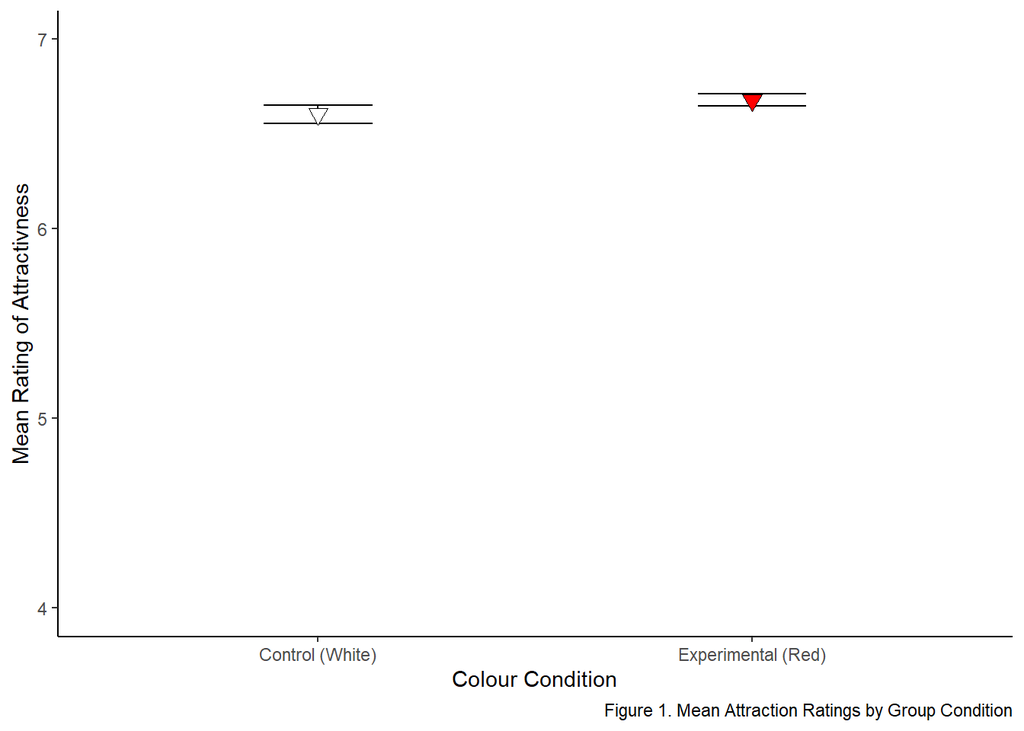

# **Discussion**

*Implications* In regard to replicating Elliot et al (2010), the results from this study are in line with their findings in Experiment 1, but at a smaller level of significance. This study had more participants (145) compared to Experiment 1 in Elliot et al (2010), where they only had 21 participants (p.403). This means the study replicated Elliot et al, but on a larger scale, however the difference in means is a lot smaller than expected compared to Elliot et al. This could mean that their smaller participant sample may have aided their significant result. Perhaps a larger participant sample eradicates a bigger red effect compared to that seen with a much smaller sample, but it is difficult to be sure of the validity around sample size until further studies are conducted. Heslinger, Goldbach and Carbon (2015) attempted to replicate Elliot et al (2010), but they claimed that none of their replications showed a significant effect of red, suggesting that “the red effect probably is not as robust as the multiple successful replications reported” (p.1147) in Elliot et al (2010). Peperkoorn, Roberts and Pollet (2016) conducted experiments looking at the red effect on women’s attractiveness according to men, but did not find one, having to accept the null hypothesis (p.11). By having found a small red effect in this study, it does match up with the pattern seen in Elliot et al (2010), but with two other studies (mentioned above) having to accept the null, introduces some level of uncertainty or unpredictability of the red effect. In relation to this uncertainty there was criticism from Francis (2013) about publication bias in Elliot et al (2010), which Elliot and Maier (2013) responded to. Within this, Elliot and Maier even replicated their study in the reply to Francis (2013), where they found the same effect as in their original study, but without statistical significance. They then state that future studies would need “a larger, more powerful sample to detect a significant effect” (p.298). The implications of this study are not as impactful as they could have been, but this does open an avenue for future research to benefit from.

*Limitations and Future Research* The limitations of this study begin with the number of participants, as previously mentioned. It is a larger sample than the original study, but the effect seems smaller in the results. Future studies should try to replicate it with a larger number of participants, perhaps 200 plus, and then see if a larger sample size yields a similar effect size as this current study, or a larger effect. More replications with larger samples will result in resolving the uncertainty around these studies examining colour, since there are many replications which accept the null hypothesis. The design of the study, although a replication, could have had more conditions to allow clearer results. Peperkoorn et al (2016) used clothing colour on women to see if it had an effect, so further research could involve new conditions, such as a white or a red t-shirt a man could wear in a photograph, along with the original conditions of this study and Elliot et al’s (2010). An extra two conditions could have added to the data in this study, maybe encouraging a more secure significance statistic. Also, the study may have been aided by having two or three different men shown in a photograph, as narrowing one man down to being fairly attractive to all women is hardly possible. Having a variety of fairly attractive men, of different races or hair colours would help. This would open up more generalisability of the results, rather than having women (most likely from different cultures) looking at a Caucasian man who may not be their idea of attractive. To do this, future studies should run a pre-experimental test of varying ‘types’ of men that women would consider attractive, to be aware of the men that should be displayed due to being most generalisable. This would reduce the issue of a woman rating a man as less attractive purely because he is not their typical idea of attractive, meaning the results will be more valid.

*Conclusion* The results from this study did support the hypothesis that the colour of the background, being white or red, of one man’s photograph will have an effect on the participant’s mean ratings of the perceived attractiveness of the man. The research question has been answered too, in that the red effect is replicable and can be seen within the data collected, the *p*-value being .028 and the significance value being .05. This statistical significance supports the findings of Elliot et al (2010) in that there is a red effect, however there are other studies to suggest the opposite. This is why further research needs to be conducted, with a better design and a large participant sample, to establish whether this effect is really there, or if it is actually just chance. The effects of colour are still not truly discernible, but with further research this could be resolved.

# References

Elliot, A. J., Kayser, D. N., Greitemeyer, T., Lichtenfeld, S., Gramzow, R. H., Maier, M. A. & Liu, H. (2010). Red, Rank and Romance in Women Viewing Men. *Journal of Experimental Psychology: General, Volume 139, Issue 3, Pages 399-417.*

Francis, G. (2013). Publication Bias in “Red, Rank and Romance in Women Viewing Men”, by Elliot et al (2010). *Journal of Experimental Psychology: General, Volume 142, Pages 292-296.* **Cited in:** Elliot, A. J., & Maier, M. A. (2013) The Red-Attractiveness Effect, Applying the Ioannidis and Trikalinos (2007b) Test, and the Broader Scientific Context: A Reply to Francis (2013). *Journal of Experimental Psychology: General, Volume 142, Issue 1, Pages 297-300.*

Heslinger, V. M., Goldbach, L. & Carbon, C. C. (2015). Men in Red: A Re-examination of the Red-Attractiveness Effect. *Psychonomic Bulletin & Review, Volume 22, Issue 4, Pages 1142-1148.*

Peperkoorn, L. S., Roberts, S. C. & Pollet, T. V. (2016). Revisiting the Red Effect on Attractiveness and Sexual Receptivity: No Effect of the Color Red on Human Mate Preferences. *Evolutionary Psychology, Volume 14, Issue 4, Pages 1-13.*